# Exploring Red Wine by Reem Hazim

This dataset contains information about red variants of the Portuguese “Vinho Verde” wine. The dataset was created using objective tests on samples of the red wine, such as pH and density. The wine quality is the median score provided by three wine experts, who gave the sample a score between 0 and 10.

# Univariate Plots Section

```
##        X          fixed.acidity   volatile.acidity  citric.acid
##  Min.   :   1.0   Min.   : 4.60   Min.   :0.1200   Min.   :0.000
##  1st Qu.: 400.5   1st Qu.: 7.10   1st Qu.:0.3900   1st Qu.:0.090
##  Median : 800.0   Median : 7.90   Median :0.5200   Median :0.260
##  Mean   : 800.0   Mean   : 8.32   Mean   :0.5278   Mean   :0.271
##  3rd Qu.:1199.5   3rd Qu.: 9.20   3rd Qu.:0.6400   3rd Qu.:0.420
##  Max.   :1599.0   Max.   :15.90   Max.   :1.5800   Max.   :1.000
##  residual.sugar     chlorides       free.sulfur.dioxide
##  Min.   : 0.900   Min.   :0.01200   Min.   : 1.00
##  1st Qu.: 1.900   1st Qu.:0.07000   1st Qu.: 7.00
##  Median : 2.200   Median :0.07900   Median :14.00
##  Mean   : 2.539   Mean   :0.08747   Mean   :15.87
##  3rd Qu.: 2.600   3rd Qu.:0.09000   3rd Qu.:21.00
##  Max.   :15.500   Max.   :0.61100   Max.   :72.00
##  total.sulfur.dioxide    density             pH          sulphates
##  Min.   :  6.00       Min.   :0.9901   Min.   :2.740   Min.   :0.3300
##  1st Qu.: 22.00       1st Qu.:0.9956   1st Qu.:3.210   1st Qu.:0.5500
##  Median : 38.00       Median :0.9968   Median :3.310   Median :0.6200
##  Mean   : 46.47       Mean   :0.9967   Mean   :3.311   Mean   :0.6581
##  3rd Qu.: 62.00       3rd Qu.:0.9978   3rd Qu.:3.400   3rd Qu.:0.7300
##  Max.   :289.00       Max.   :1.0037   Max.   :4.010   Max.   :2.0000
##     alcohol         quality
##  Min.   : 8.40   Min.   :3.000
##  1st Qu.: 9.50   1st Qu.:5.000
##  Median :10.20   Median :6.000
##  Mean   :10.42   Mean   :5.636
##  3rd Qu.:11.10   3rd Qu.:6.000
##  Max.   :14.90   Max.   :8.000
```

```
## 'data.frame':    1599 obs. of  13 variables:
##  $ X                   : int  1 2 3 4 5 6 7 8 9 10 ...
##  $ fixed.acidity       : num  7.4 7.8 7.8 11.2 7.4 7.4 7.9 7.3 7.8 7.5 ...
##  $ volatile.acidity    : num  0.7 0.88 0.76 0.28 0.7 0.66 0.6 0.65 0.58 0.5 ...
##  $ citric.acid         : num  0 0 0.04 0.56 0 0 0.06 0 0.02 0.36 ...
##  $ residual.sugar      : num  1.9 2.6 2.3 1.9 1.9 1.8 1.6 1.2 2 6.1 ...
##  $ chlorides           : num  0.076 0.098 0.092 0.075 0.076 0.075 0.069 0.065 0.073 0.071 ...
##  $ free.sulfur.dioxide : num  11 25 15 17 11 13 15 15 9 17 ...
##  $ total.sulfur.dioxide: num  34 67 54 60 34 40 59 21 18 102 ...
##  $ density             : num  0.998 0.997 0.997 0.998 0.998 ...
##  $ pH                  : num  3.51 3.2 3.26 3.16 3.51 3.51 3.3 3.39 3.36 3.35 ...
##  $ sulphates           : num  0.56 0.68 0.65 0.58 0.56 0.56 0.46 0.47 0.57 0.8 ...
##  $ alcohol             : num  9.4 9.8 9.8 9.8 9.4 9.4 9.4 10 9.5 10.5 ...
##  $ quality             : int  5 5 5 6 5 5 5 7 7 5 ...
```

```
## [1] 1599   13
```

This dataset has around 1600 observations with 13 variables. I noticed that the quality variable has the data type of integer, even though it’s better regarded as an ordered factor. I’ll change its data type to an ordered factor.

```
## 'data.frame':    1599 obs. of  13 variables:
##  $ X                   : int  1 2 3 4 5 6 7 8 9 10 ...
##  $ fixed.acidity       : num  7.4 7.8 7.8 11.2 7.4 7.4 7.9 7.3 7.8 7.5 ...
##  $ volatile.acidity    : num  0.7 0.88 0.76 0.28 0.7 0.66 0.6 0.65 0.58 0.5 ...
##  $ citric.acid         : num  0 0 0.04 0.56 0 0 0.06 0 0.02 0.36 ...
##  $ residual.sugar      : num  1.9 2.6 2.3 1.9 1.9 1.8 1.6 1.2 2 6.1 ...
##  $ chlorides           : num  0.076 0.098 0.092 0.075 0.076 0.075 0.069 0.065 0.073 0.071 ...
##  $ free.sulfur.dioxide : num  11 25 15 17 11 13 15 15 9 17 ...
##  $ total.sulfur.dioxide: num  34 67 54 60 34 40 59 21 18 102 ...
##  $ density             : num  0.998 0.997 0.997 0.998 0.998 ...
##  $ pH                  : num  3.51 3.2 3.26 3.16 3.51 3.51 3.3 3.39 3.36 3.35 ...
##  $ sulphates           : num  0.56 0.68 0.65 0.58 0.56 0.56 0.46 0.47 0.57 0.8 ...
##  $ alcohol             : num  9.4 9.8 9.8 9.8 9.4 9.4 9.4 10 9.5 10.5 ...
##  $ quality             : Ord.factor w/ 11 levels "0"<"1"<"2"<"3"<..: 6 6 6 7 6 6 6 8 8 6 ...
```

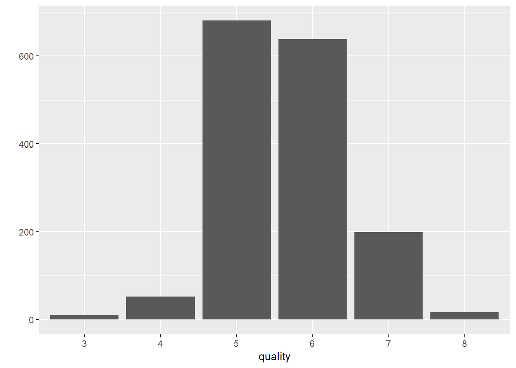

There seems to be no wine samples with quality less than 3 or greater than 8. Most samples received a score of 5 or 6, and very few received a 3 or an 8.

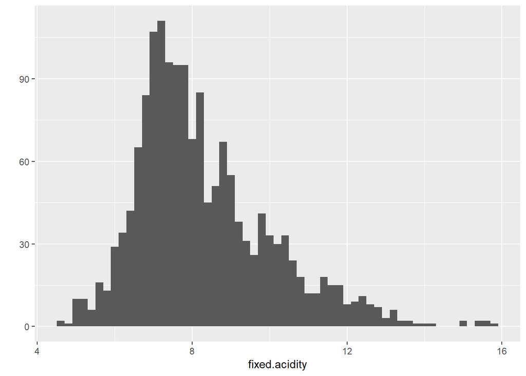

There seems to be a gap at around 14.5. Also, the fixed acidity seems to follow a normal distribution, peaking at around 7.5. I wonder if that’s true for volatile acidity as well.

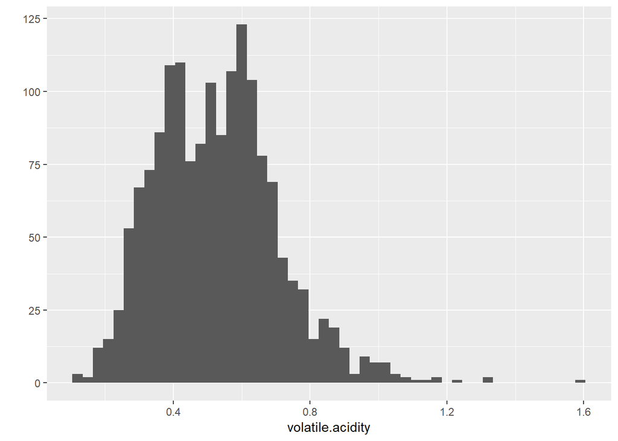

The volatile acidity, on the other hand, seems to follow a bimodal distribution, peaking at 0.4 and 0.6. There is also an outlier with a volatile acidity of almost 1.6. According to the text file, wine with too high volatile acidity will have “an unpleasant, vinegar taste”. This sample must have received a very low score for quality.

```
##         X fixed.acidity volatile.acidity citric.acid residual.sugar
## 1300 1300           7.6             1.58           0            2.1
##      chlorides free.sulfur.dioxide total.sulfur.dioxide density  pH
## 1300     0.137                   5                    9 0.99476 3.5
##      sulphates alcohol quality
## 1300       0.4    10.9       3
```

My guess was true. The sample received a score of 3 for quality, which is the minimum score in this dataset.

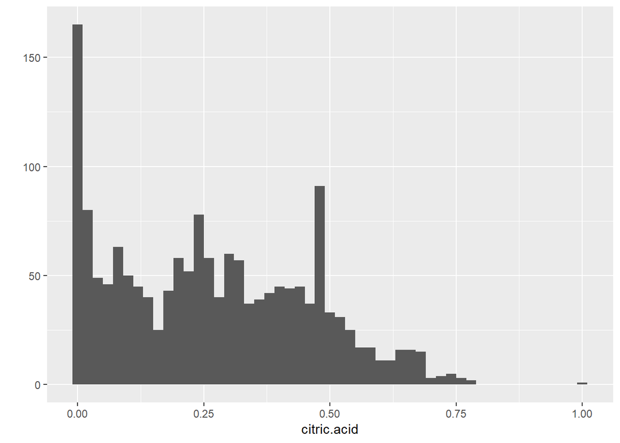

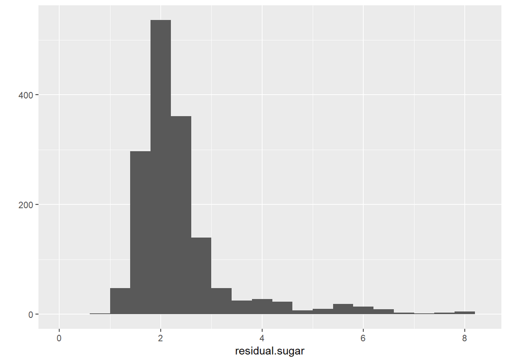

The residual sugar histogram seems to be skewed to the right. I’ll apply a log transformation to understand it better. There also seems to be several outliers afetr 9.

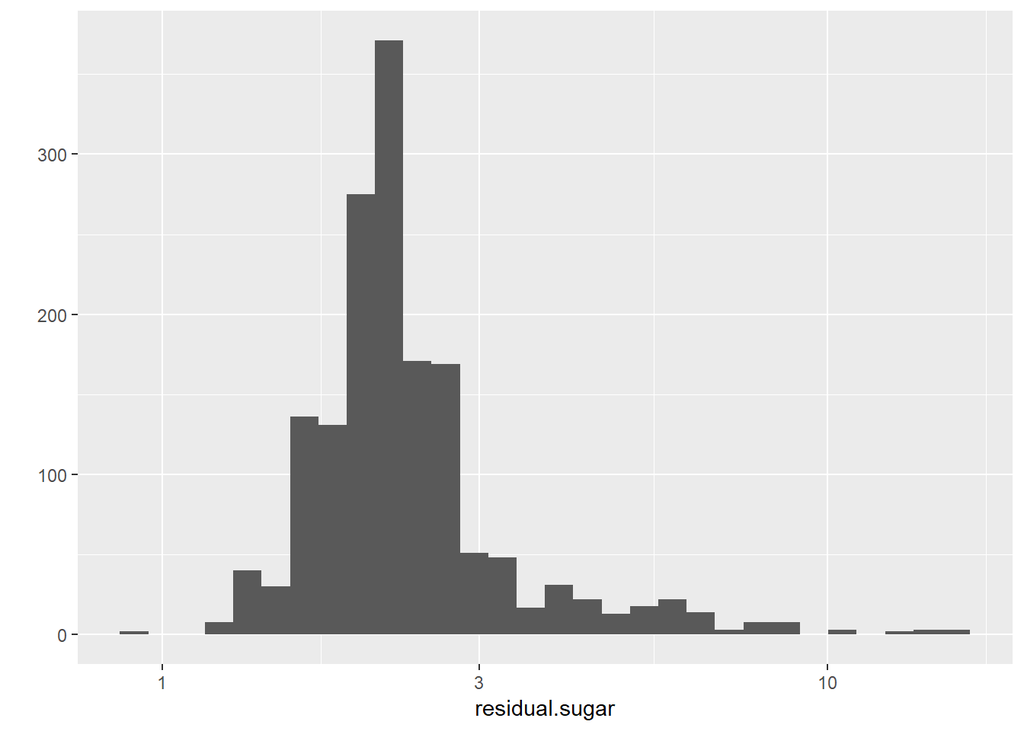

There appears to be a normal distribution here, and the transformed distribution peaks at around 2.5.

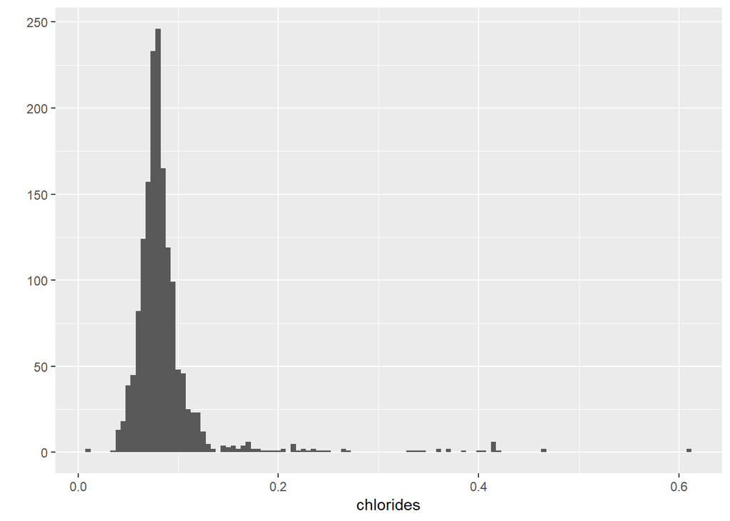

The chlorides (amount of salt) in the wine appears to have a normal ditribution with many outliers. Let’s zoom in on the plot.

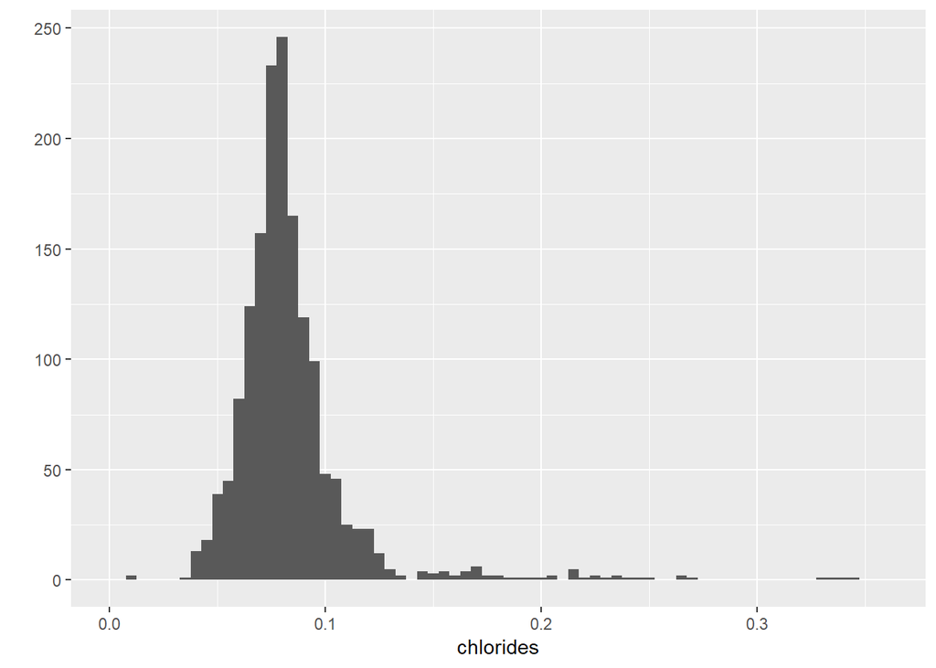

```
##    Min. 1st Qu.  Median    Mean 3rd Qu.    Max.
## 0.01200 0.07000 0.07900 0.08747 0.09000 0.61100
```

The mean of chlorides is 0.087, while the median is 0.079. The mean was probably affected by the many outliers in the distribution, which is why it’s higher than the median.

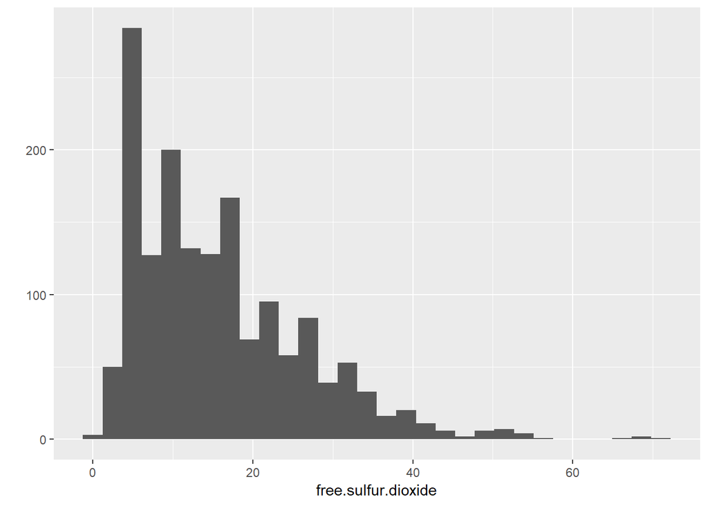

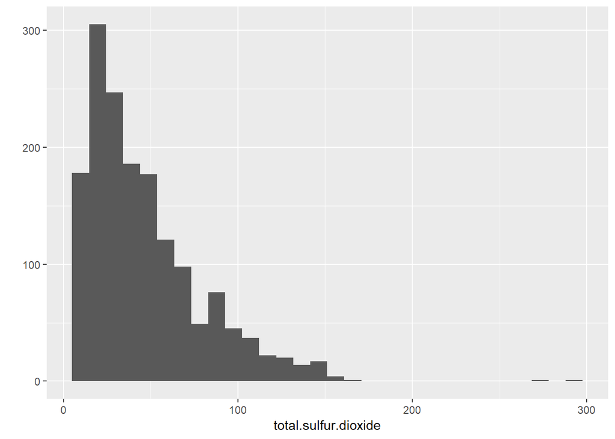

Both the graphs of total sulfur dioxide and free sulfur dioxide are skewed to the right. In addition, there are a couple of outliers in both. Let’s see what happens when we transform them using log.

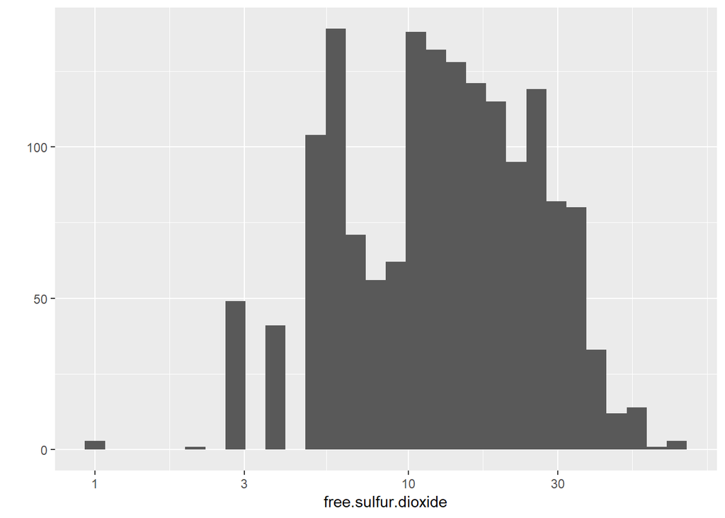

I wonder whether certain values of free sulfur dioxide result in higher quality.

```
##  [1] 11.0 25.0 15.0 17.0 13.0  9.0 16.0 52.0 51.0 35.0  6.0 29.0 23.0 10.0
## [15] 21.0  4.0 14.0  8.0 22.0 40.0  5.0  3.0  7.0 12.0 30.0 33.0 50.0 19.0
## [29] 20.0 27.0 18.0 28.0 34.0 42.0 41.0 37.0 32.0 36.0 24.0 26.0 39.0 40.5
## [43] 68.0 31.0 38.0 43.0 47.0  1.0 54.0 46.0 45.0  2.0  5.5 53.0 37.5 57.0
## [57] 48.0 72.0 55.0 66.0
```

There are several unique values for free sulfur dioxide.

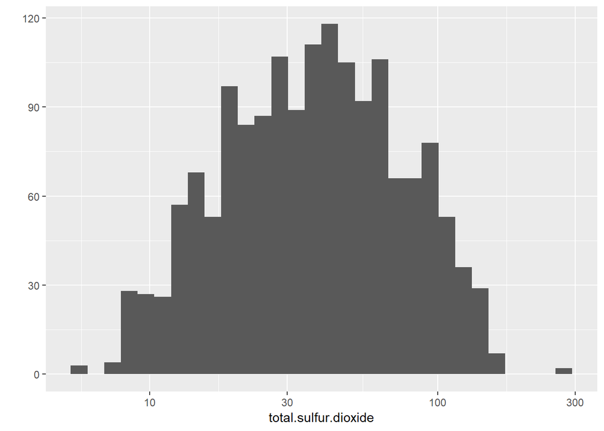

I can see that the same is true for total sulfur dioxide. The transformed distribution follows a bell-shaped curve and falls on certain values.

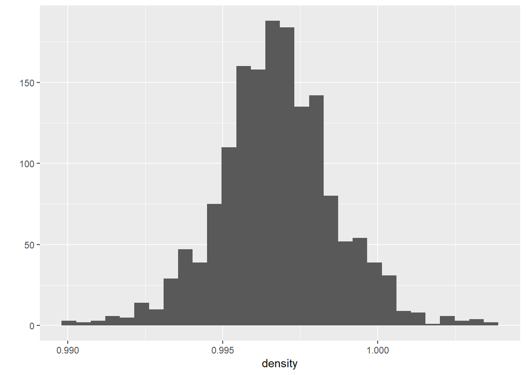

The density has a normal distribution. Moreover, the text file tells us that “the density of wine is close to that of water depending on the percent alcohol and sugar content”. As such, it makes sense that most of the values are very close to 1. I wonder what the relation between density, alcohol, and residual sugar is.

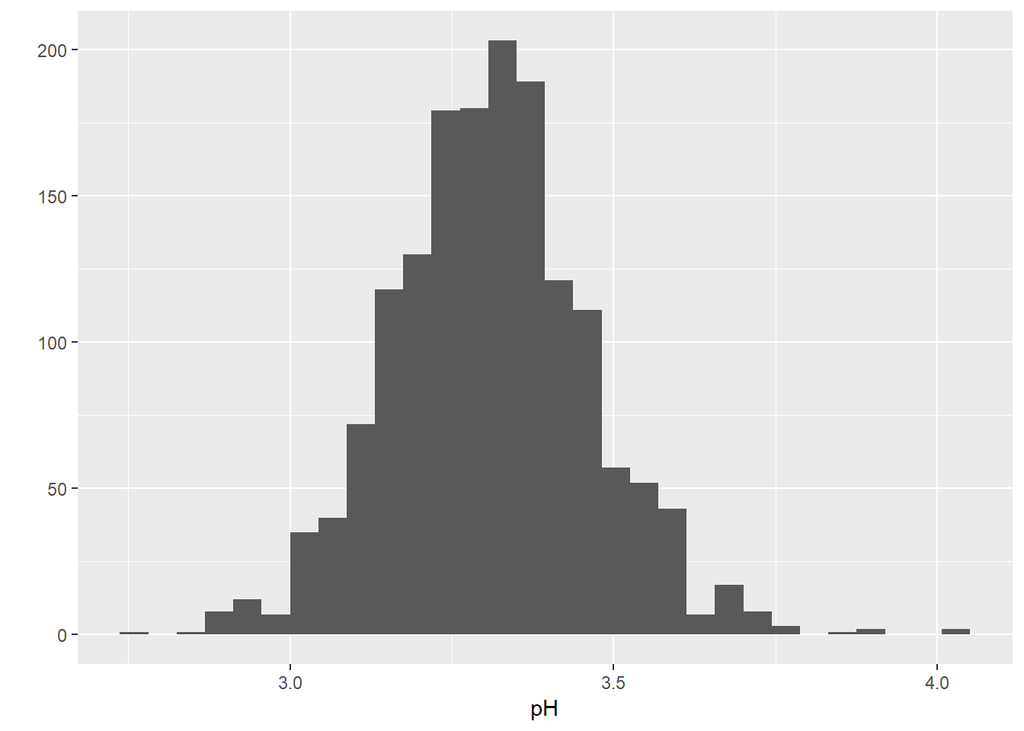

pH also follows a normal distribution where most samples have a pH of around 3.310. Since pH is related to acidity, I would like to explore how pH relates to the volatile acidity and fixed acidity.

```
##    Min. 1st Qu.  Median    Mean 3rd Qu.    Max.
##   2.740   3.210   3.310   3.311   3.400   4.010
```

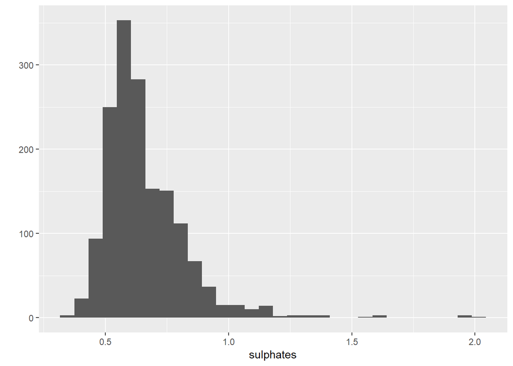

Aside from a few outliers, the sulphates distribution seems normal. I’ll omit the top 1% of observations from the plot and zoom in on the plot.

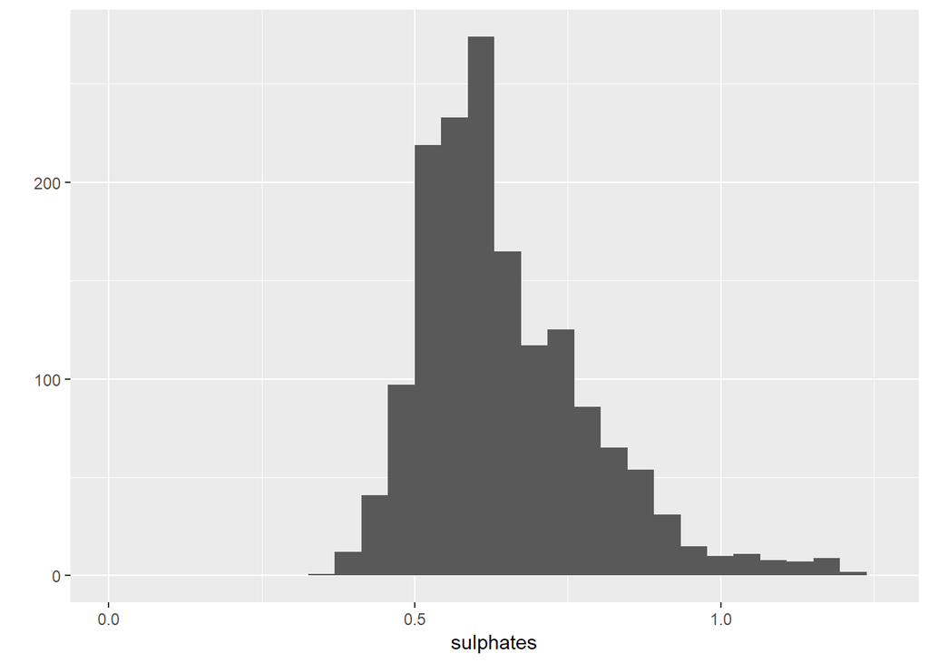

The distribution looks more like a bell curve now. I wonder how the amount of sulfates influences the amount of free and total sulfur dioxide in the wine samples.

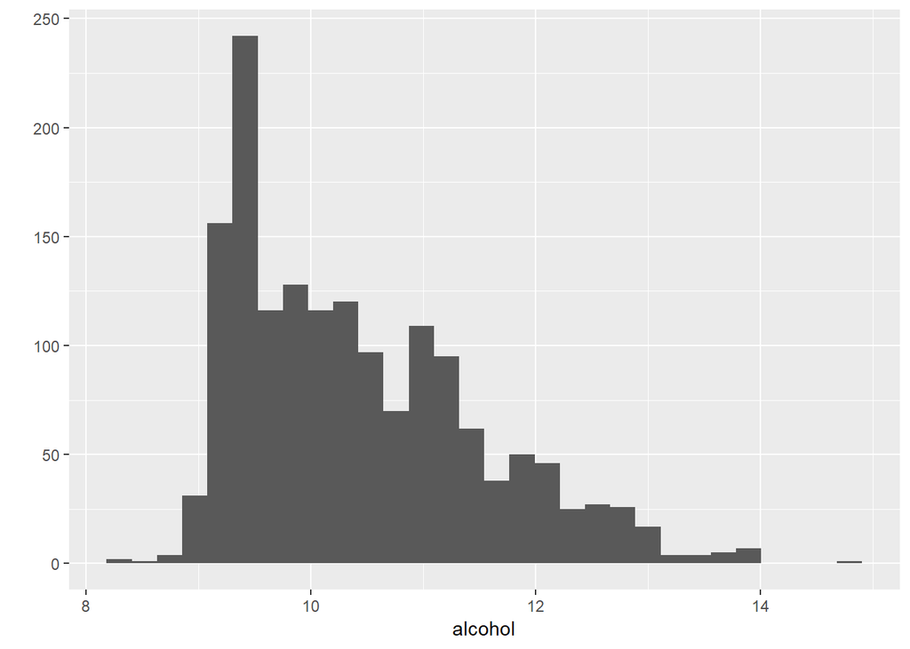

Alcohol percentage has a right-skewed distribution that peaks at around 9.5%. I will transform the distribution using log.

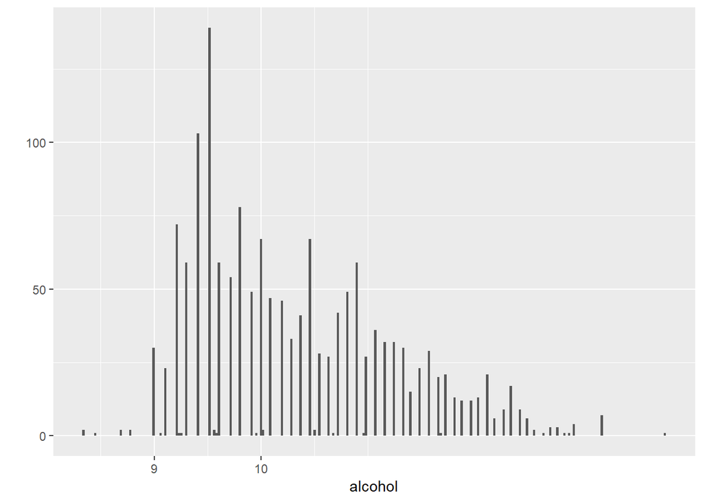

The distribution is still slightly skewed to the right. I wonder if the alcohol percentage has any influence on the wine quality, or whether the pH of a wine sample has any effect on its alcohol level. Perhaps a numeric summary will give me more insight into this.

```
##    Min. 1st Qu.  Median    Mean 3rd Qu.    Max.
##    8.40    9.50   10.20   10.42   11.10   14.90
```

Since the data is skewed to the right, the mean is greater than the median. There’s also an outlier at 14.90, which is the maximum value for alcohol.

```
##
##              8.4              8.5              8.7              8.8
##                2                1                2                2
##                9             9.05              9.1              9.2
##               30                1               23               72
## 9.23333333333333             9.25              9.3              9.4
##                1                1               59              103
##              9.5             9.55 9.56666666666667              9.6
##              139                2                1               59
##              9.7              9.8              9.9             9.95
##               54               78               49                1
##               10 10.0333333333333             10.1             10.2
##               67                2               47               46
##             10.3             10.4             10.5            10.55
##               33               41               67                2
##             10.6             10.7            10.75             10.8
##               28               27                1               42
##             10.9               11 11.0666666666667             11.1
##               49               59                1               27
##             11.2             11.3             11.4             11.5
##               36               32               32               30
##             11.6             11.7             11.8             11.9
##               15               23               29               20
##            11.95               12             12.1             12.2
##                1               21               13               12
##             12.3             12.4             12.5             12.6
##               12               13               21                6
##             12.7             12.8             12.9               13
##                9               17                9                6
##             13.1             13.2             13.3             13.4
##                2                1                3                3
##             13.5 13.5666666666667             13.6               14
##                1                1                4                7
##             14.9
##                1
```

The most repeated value is 9.5, as we can tell by the histogram. There are also some unique values around 9.5 that only occur a few times, such as 9.56667, 9.55 and 9.95, which is why we see so many valleys and dips in the distribution.

# Univariate Analysis

### What is the structure of your dataset?

My dataset has 1599 observations with 13 variables. There is only one ordered factor, wine quality, which is on a scale of 0 - 10, with 0 being worst quality and 10 being best quality. In this dataset, however, none of the samples received lower than a 3 or higher than an 8 for quality.

### What is/are the main feature(s) of interest in your dataset?

The main feature of interest in my dataset is the wine quality. I would like to explore how the other variables influence wine quality in my bivariate and multivariate analyses.

### What other features in the dataset do you think will help support your investigation into your feature(s) of interest?

The pH and the volatile and fixed acidity may also have an influence on wine quality. I will explore their relation in my bivariate and multivariate analyses. In addition, the amount of sulphates and the amount of free and total sulfur dioxide might also be dependent on each other, and I’d like to see whether they have an effect on wine quality as well.

### Did you create any new variables from existing variables in the dataset?

No. Most of my variables are measurements of wine qualities, and there was no room for any of them to be combined. I did, however, change the wine quality data type to an ordered factor to facilitate my analysis.

# Bivariate Plots Section

```
##                      fixed.acidity volatile.acidity citric.acid
## fixed.acidity           1.00000000     -0.256130895  0.67170343
## volatile.acidity       -0.25613089      1.000000000 -0.55249568
## citric.acid             0.67170343     -0.552495685  1.00000000
## residual.sugar          0.11477672      0.001917882  0.14357716
## chlorides               0.09370519      0.061297772  0.20382291
## free.sulfur.dioxide    -0.15379419     -0.010503827 -0.06097813
## total.sulfur.dioxide   -0.11318144      0.076470005  0.03553302
## density                 0.66804729      0.022026232  0.36494718
## pH                     -0.68297819      0.234937294 -0.54190414
## sulphates               0.18300566     -0.260986685  0.31277004
## alcohol                -0.06166827     -0.202288027  0.10990325
##                      residual.sugar    chlorides free.sulfur.dioxide
## fixed.acidity           0.114776724  0.093705186        -0.153794193
## volatile.acidity        0.001917882  0.061297772        -0.010503827
## citric.acid             0.143577162  0.203822914        -0.060978129
## residual.sugar          1.000000000  0.055609535         0.187048995
## chlorides               0.055609535  1.000000000         0.005562147
## free.sulfur.dioxide     0.187048995  0.005562147         1.000000000
## total.sulfur.dioxide    0.203027882  0.047400468         0.667666450
## density                 0.355283371  0.200632327        -0.021945831
## pH                     -0.085652422 -0.265026131         0.070377499
## sulphates               0.005527121  0.371260481         0.051657572
## alcohol                 0.042075437 -0.221140545        -0.069408354
##                      total.sulfur.dioxide     density          pH
## fixed.acidity                 -0.11318144  0.66804729 -0.68297819
## volatile.acidity               0.07647000  0.02202623  0.23493729
## citric.acid                    0.03553302  0.36494718 -0.54190414
## residual.sugar                 0.20302788  0.35528337 -0.08565242
## chlorides                      0.04740047  0.20063233 -0.26502613
## free.sulfur.dioxide            0.66766645 -0.02194583  0.07037750
## total.sulfur.dioxide           1.00000000  0.07126948 -0.06649456
## density                        0.07126948  1.00000000 -0.34169933
## pH                            -0.06649456 -0.34169933  1.00000000
## sulphates                      0.04294684  0.14850641 -0.19664760
## alcohol                       -0.20565394 -0.49617977  0.20563251
##                         sulphates     alcohol
## fixed.acidity         0.183005664 -0.06166827
## volatile.acidity     -0.260986685 -0.20228803
## citric.acid           0.312770044  0.10990325
## residual.sugar        0.005527121  0.04207544
## chlorides             0.371260481 -0.22114054
## free.sulfur.dioxide   0.051657572 -0.06940835
## total.sulfur.dioxide  0.042946836 -0.20565394
## density               0.148506412 -0.49617977
## pH                   -0.196647602  0.20563251
## sulphates             1.000000000  0.09359475
## alcohol               0.093594750  1.00000000
```

What stands out to me is that fixed acidity has a moderate positive correlation with citric acidity. I hadn’t considered that before! I will explore their relation further in this section. Moreover, density and fixed acidity also have a moderate positive correlation, while pH and fixed acidity have a negative moderate correlation. I wonder why there isn’t much correlation between pH and volatile acidity, on the other hand.

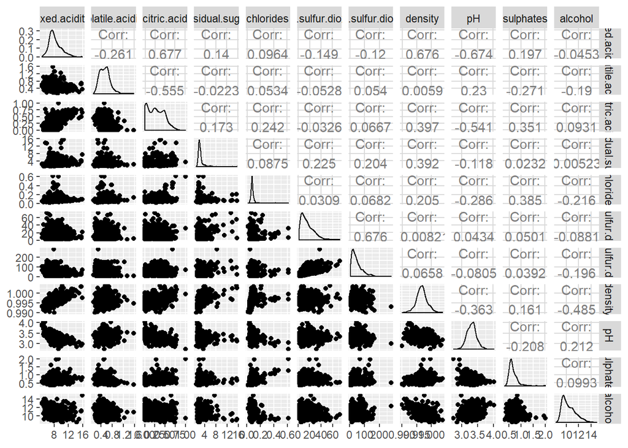

Alcohol and density seem to have a moderate negative correlation, as shown by the scatter plot and the correlation coefficient. On the other hand, residual sugar has no meaningful relation with alcohol, but it does have a small positive correlation with density.

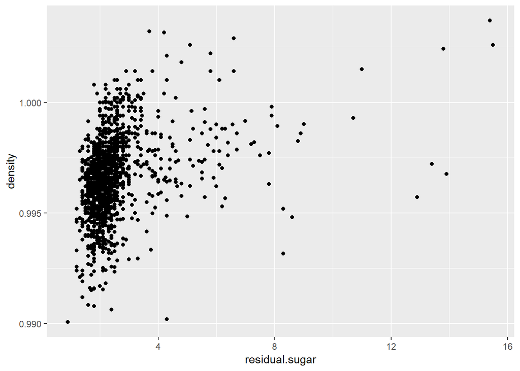

I will zoom in on the plot by omitting the top 5% of values for residual sugar.

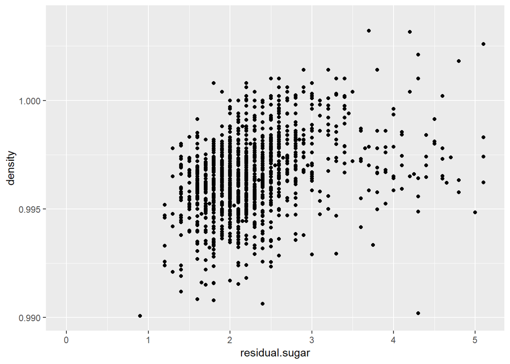

The general trend seems to be that as the amount of residual sugar increases, so does the density. This makes sense, because more residual sugar means more mass, and density is mass/volume. In addition, the vertical lines are due to many observations having the same amount of residual sugar but with different densities.

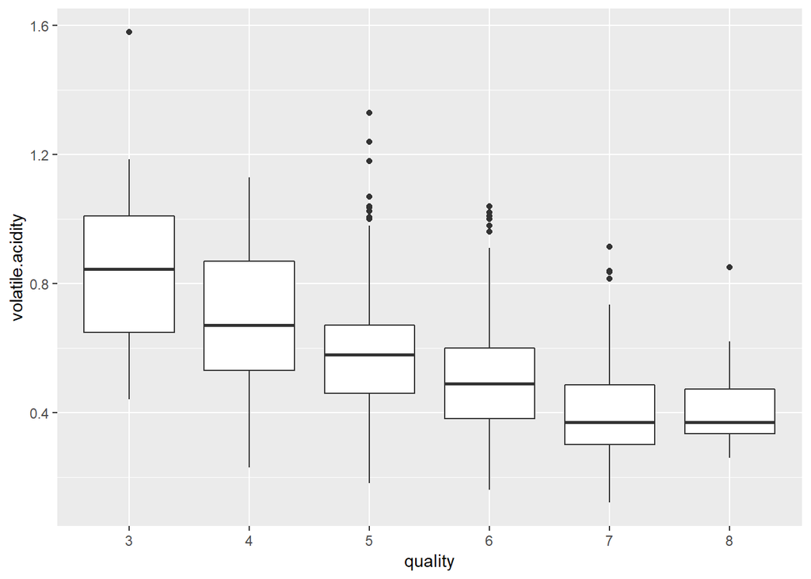

That seems interesting… Volatile acidity appears to have a strong effect on quality. The samples with the lowest quality have the highest median volatile acidity, while those with the highest quality have the least median volatile acidity. In addition, the interquartile range seems to decrease as the quality increases. I wonder if there’s a similar trend with fixed acidity.

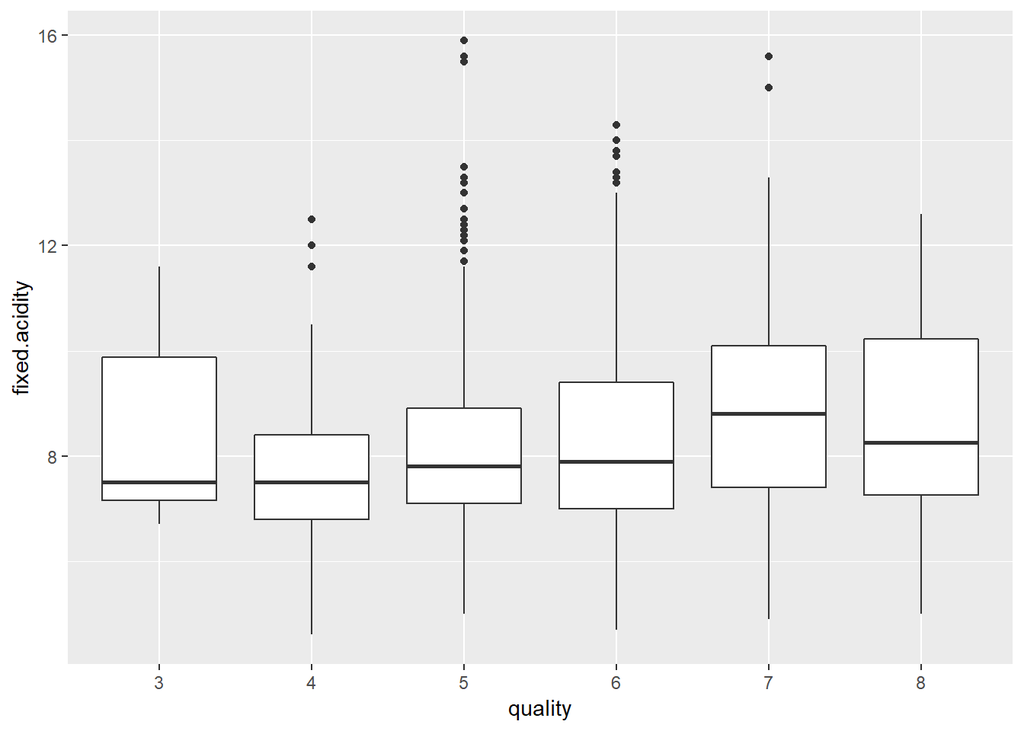

On the other hand, fixed acidity doesn’t seem to influence quality much, as the samples have a median fixed acidity of around 8 across all qualities. Let’s see whether the same is true for citric acid levels.

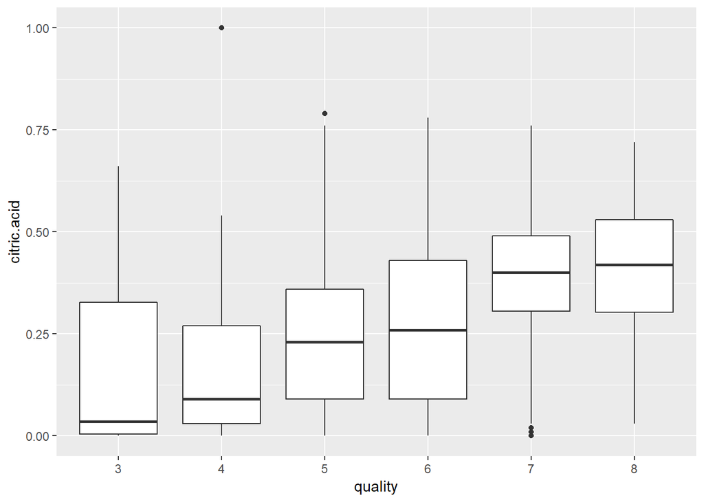

That’s surprising! Although the fixed acidity doesn’t have influence over quality, citric acid seems to greatly affect it. We can see that the wine samples with the least quality have the lowest median amount of citric acid, while those with the highest quality have the highest median amount of citric acid.

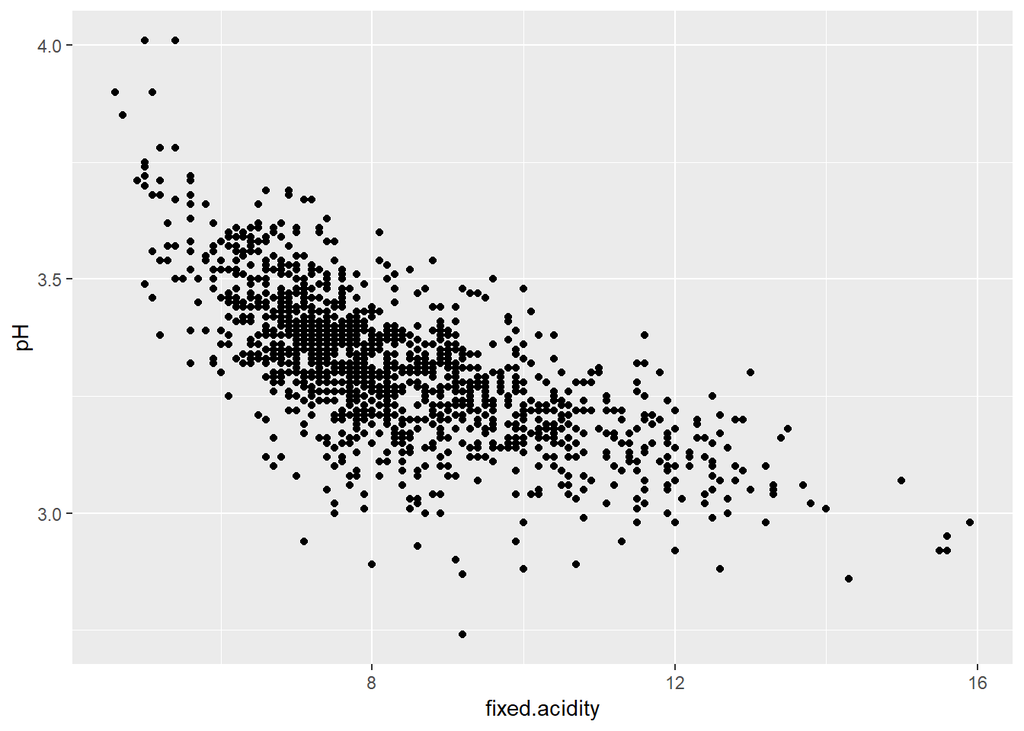

There also seems to be a general decreasing trend for pH and fixed acidity. The samples with the lowest fixed acidity have the highest pH. I want to see whether we can spot similar trends for volatile acidity and pH. In addition, there are strange small gaps occurring almost periodically.

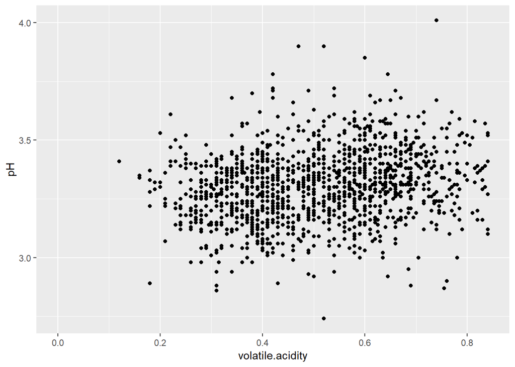

That’s strange… There seems to be no trend at all when we plot volatile acidity versus pH.

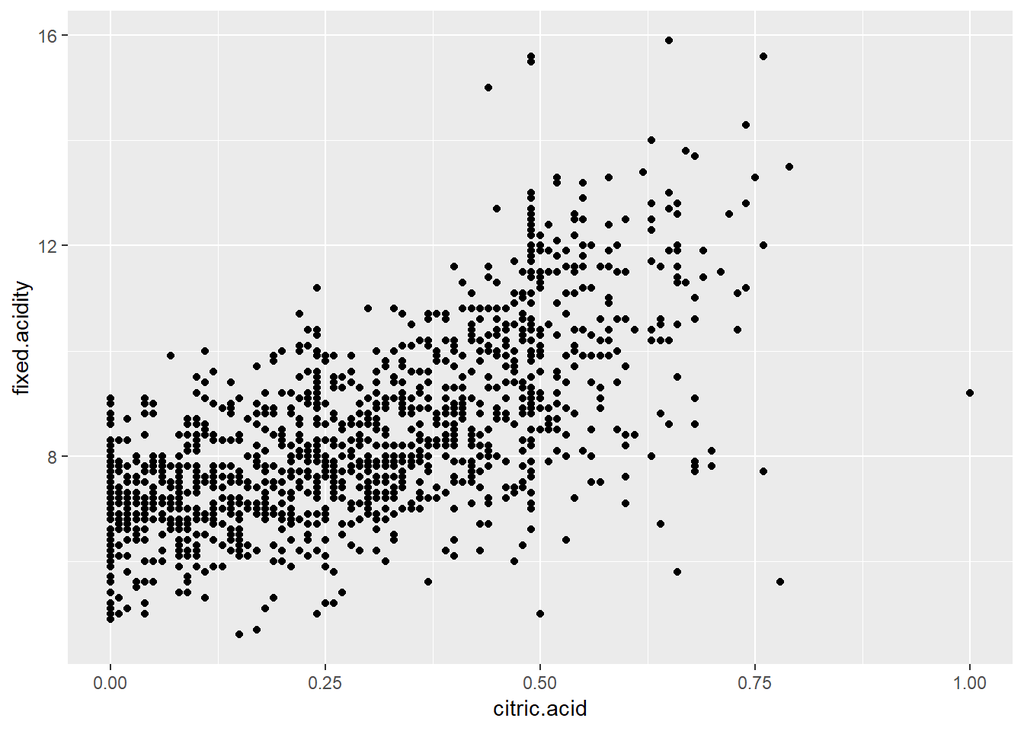

Generally, there’s an increasing trend for citric acid and fixed acidity. However, after doing some research, I discovered that citric acid is counted as part of the fixed acidity. This is why it’s logical that as the amount of citric acid increases, the fixed acidity increases as well. Interestingly, there are especially long vertical lines at the citric acid values of 0, 0.25 and 0.5. There’s a wide range of fixed acidity values at these citric acid values, but why?

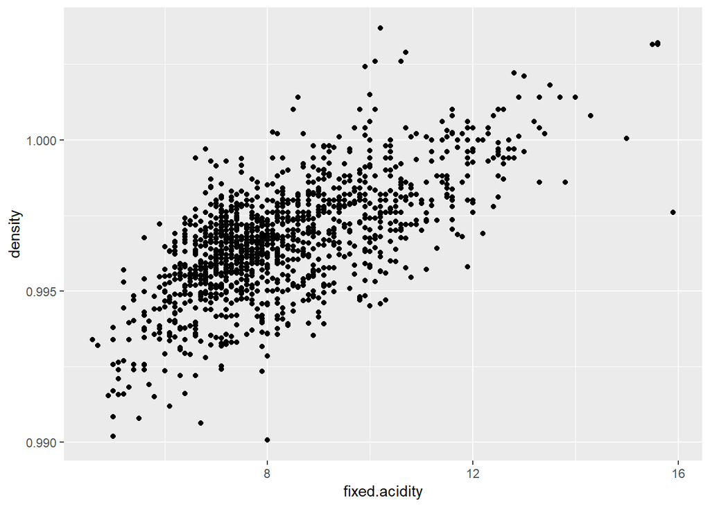

The fixed acidity also seems to have an effect on density. This is probably for the same reason as residual sugar has an effect on density, because as the amount of acids increase, the mass increases, adding more density.

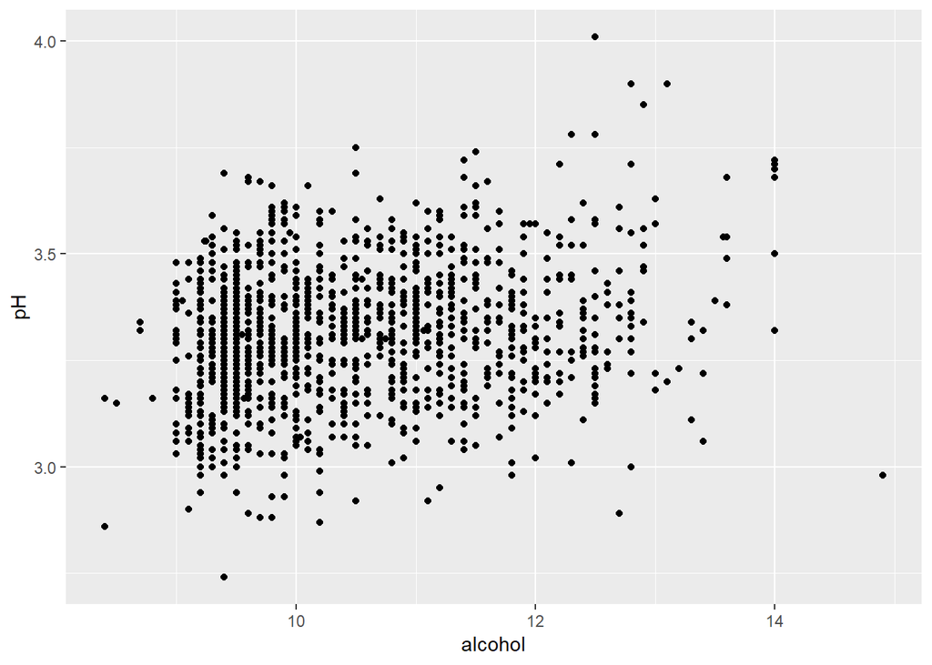

This one seems to be another dead end. Alcohol percentage doesn’t seem to influence the pH of a wine at all.

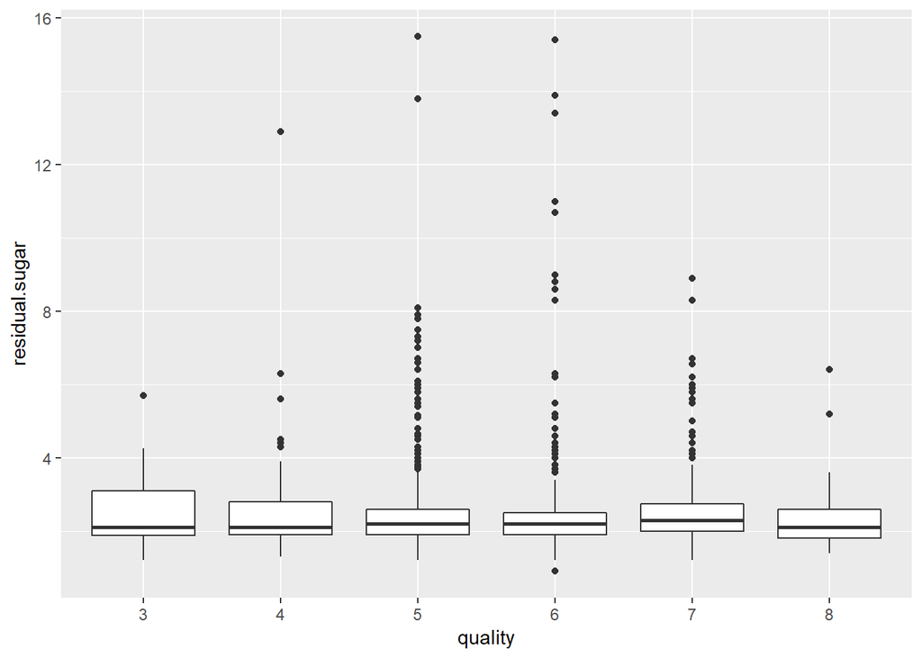

Residual sugar also doesn’t seem to be affecting the quality. What about the density?

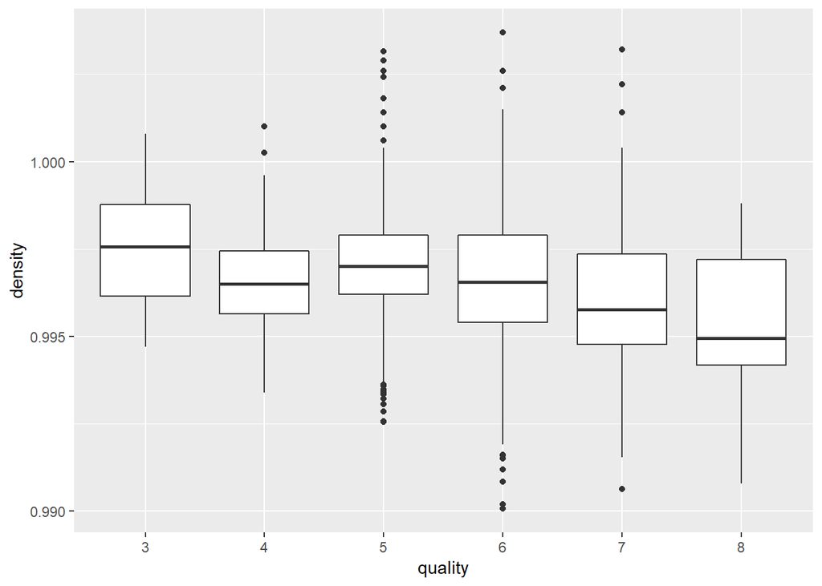

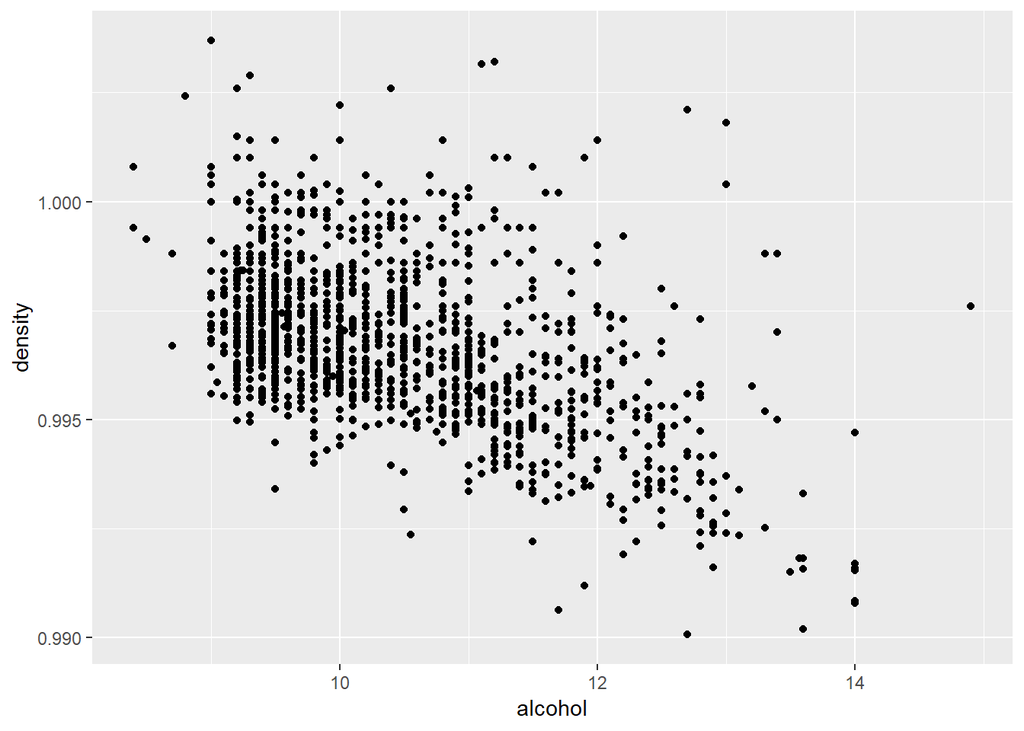

That’s unexpected! I thought that as alcohol percentage increases, the density would increase. However, it turns out that the contrary is true, as the density is highest when the alcohol percentage is very low, and the density is lowest when the alcohol percentage is very high. This would suggest that having a lower alcohol percentage corresponds to lower quality. Let’s check if this is true.

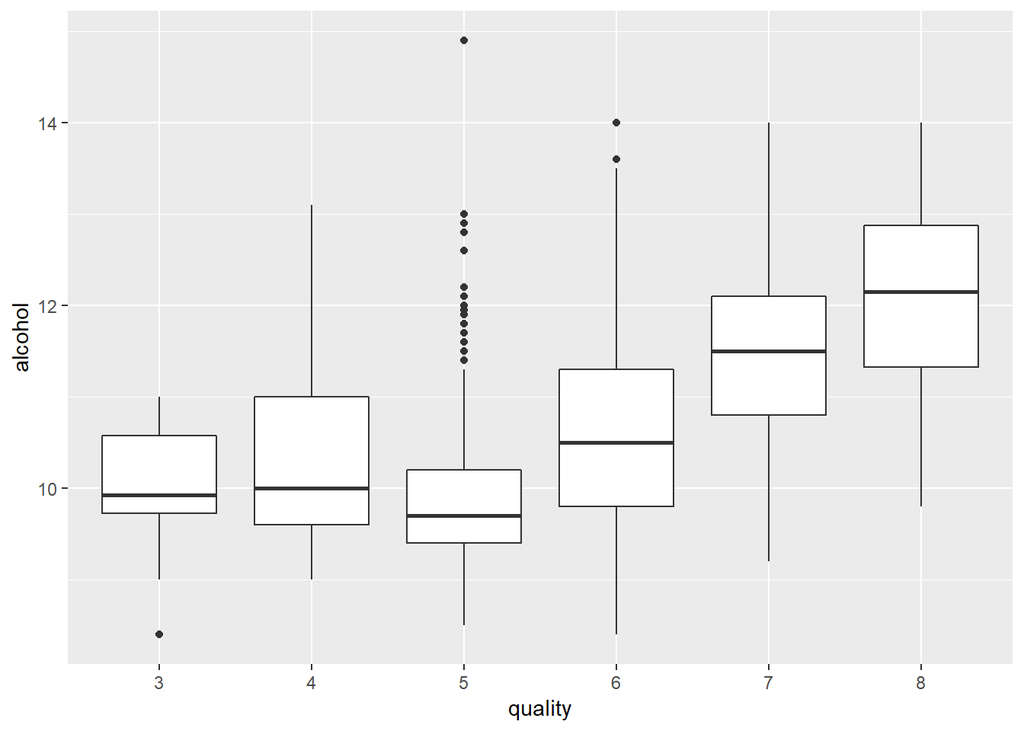

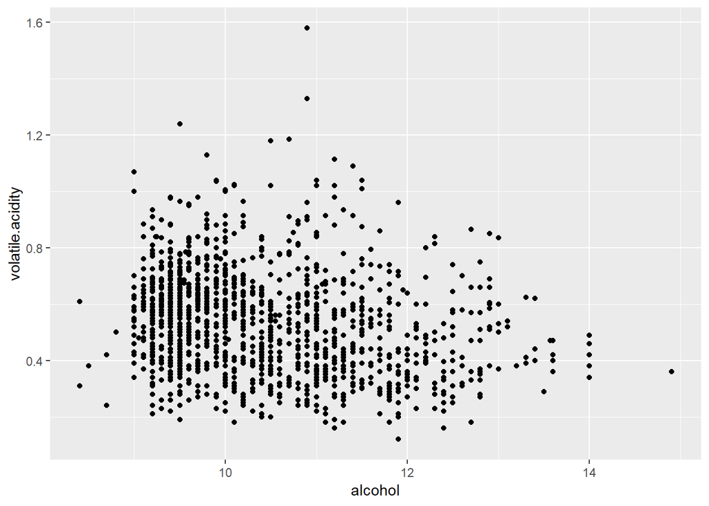

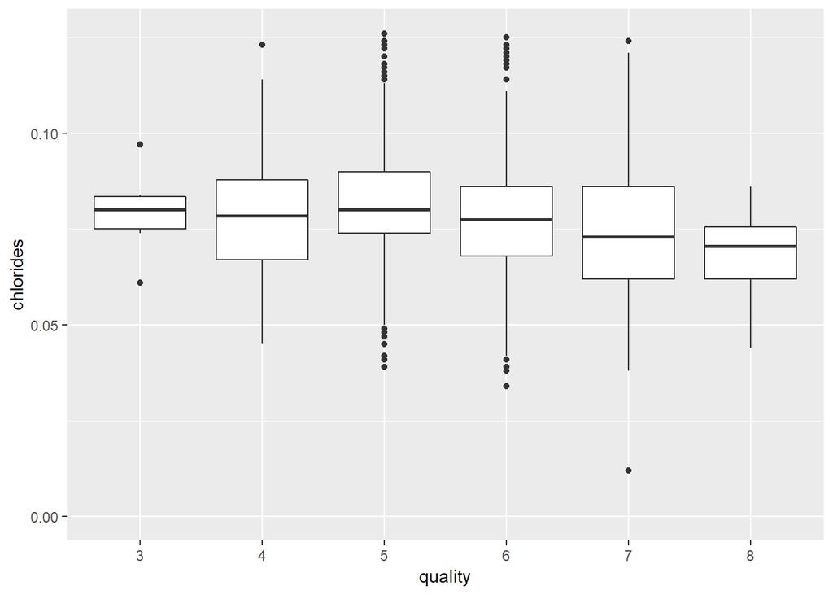

The wine samples with a quality of 5 or greater seem to decrease slightly in median amount of chloride. It’s a very small correlation, however.

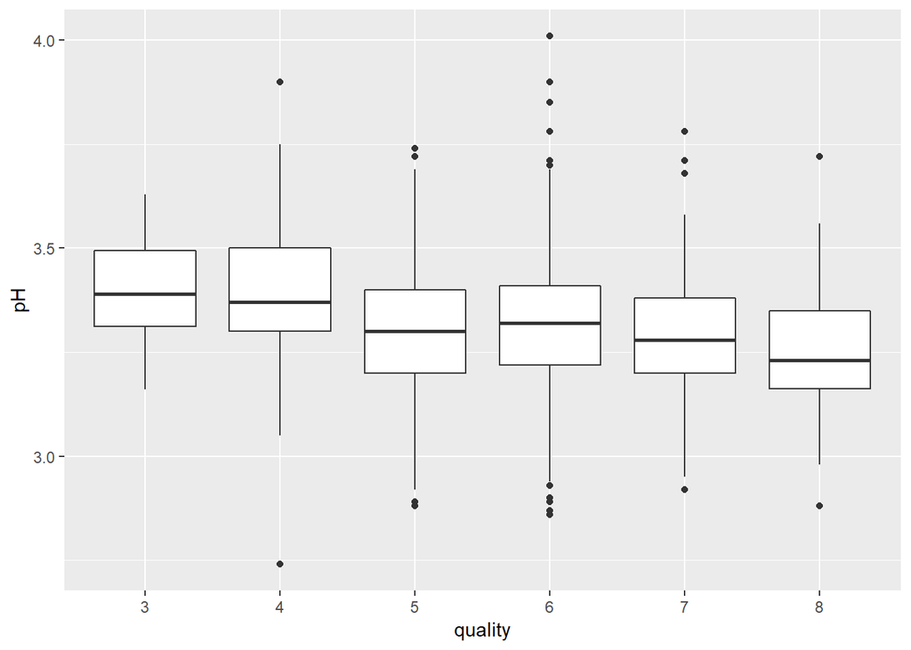

pH and quality also have a weak negative correlation!

I want to explore whether the amount of sulphates affects the amount of free and total sulfur dioxide.

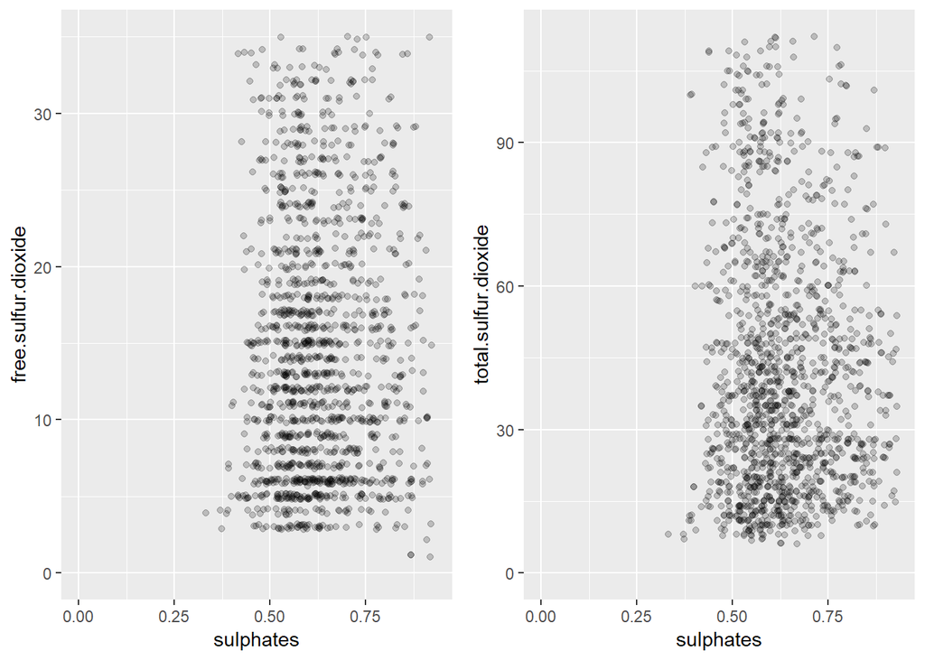

Strange… while the text file states that sulphates can contribute to the amount of sulfur dioxide in wine, this does not appear to be the case, according to the plots. We can see that most of the samples have sulphate amounts between 0.375 and 1. When we omit the top 5% of values from both the x and y axes, we can see a distinction between both graphs. While the free sulfur dioxide seems to have certain repeated values, resulting in horizontal lines across the plot, the total sulfur dioxide values are more dispersed.

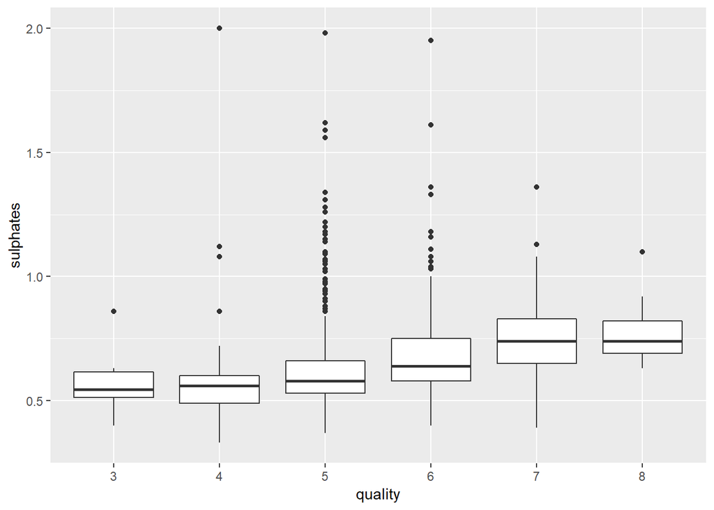

Quality seems to be influenced by sulphates as well! The median amount of sulphates is highest for samples with a wine quality of 8, and lowest for those with a quality of 3.

### Talk about some of the relationships you observed in this part of the investigation. How did the feature(s) of interest vary with other features in the dataset?

My main feature of interest, the wine quality, varied depending on the other features. I discovered that alcohol, citric acid, and sulphates have a positive influence over quality, while density, chlorides, pH and volatile acidity negativelyinfluence quality. Meanwhile, the fixed acidity and residual sugar have no effect on quality.

### Did you observe any interesting relationships between the other features (not the main feature(s) of interest)?

Yes. I discovered that residual sugar and fixed acidity have a moderate positive correlation with density, while alcohol has a negative correlation with density. In addition, there was no correlation between pH and alcohol, volatile acidity and alcohol, or volatile acidity and pH. I was surprised that there is no correlation between sulphates and free sulfur dioxide or sulphates and total sulfur dioxide. Lastly, the fixed acidity has a negative moderate correlation with pH.

### What was the strongest relationship you found?

None of my numeric variables had strong relationships (a correlation coefficient greater than 0.7), and the strongest realtionship was the one pH and fixed acidity, with a correlation factor of approximately -0.68.

# Multivariate Plots Section

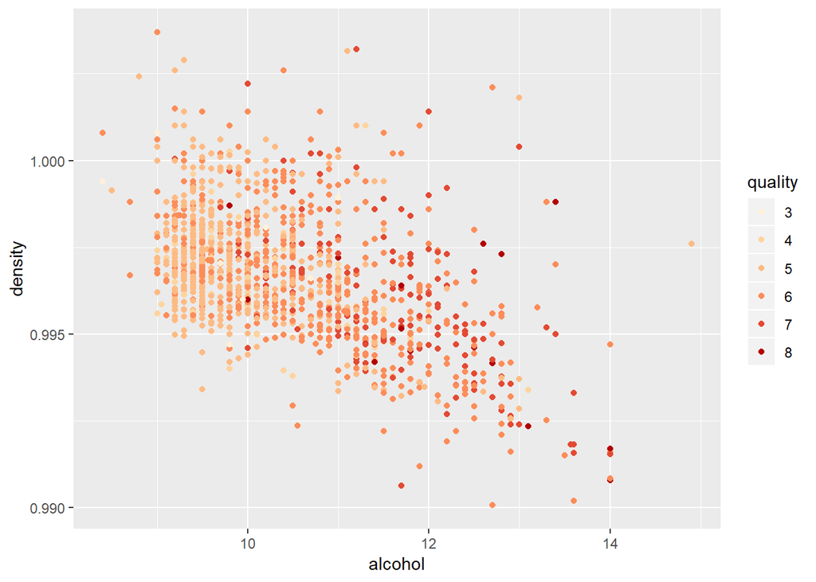

The trend we saw between quality and alcohol and between quality and density is much more clear here. Generally, samples with lower quality seem to be concentrated on the left where they have lower alcohol percentage and higher density, while those with quality of 6 or more are concentrated on the right, with lower density and higher alcohol percentage.

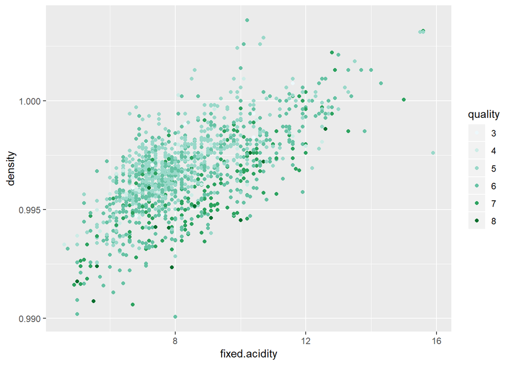

Holding the density constant, wine samples with higher fixed acidity are of higher quality. In contrast, if we hold the fixed acidity constant, we can see that the samples with higher density receive a lower score of quality than those with lower density.

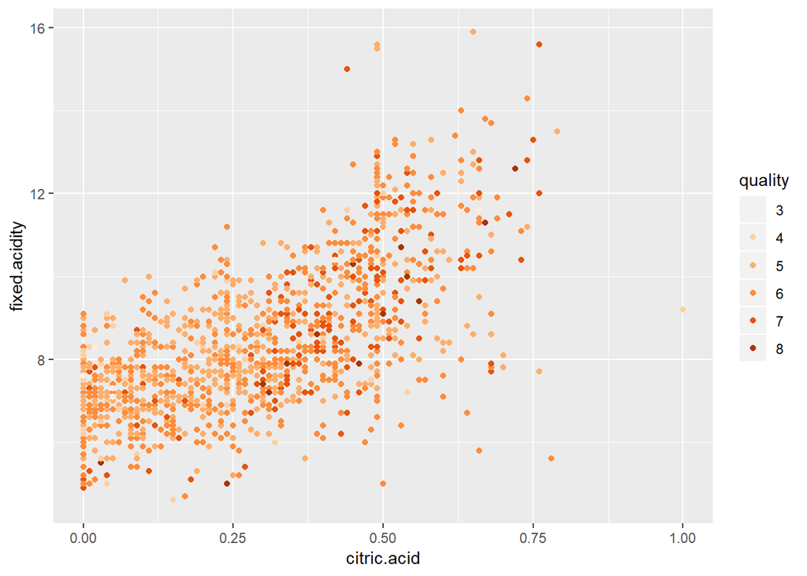

# Multivariate Analysis

### Talk about some of the relationships you observed in this part of the investigation. Were there features that strengthened each other in terms of looking at your feature(s) of interest?

Yes, fixed acidity and density seemed to strengthen each other. Although we didn’t see a strong correlation between fixed acidity and quality in the bivariate analysis, plotting fixed acidity against density revealed that the wines with the highest quality typically have low density and high fixed acidity.

### Were there any interesting or surprising interactions between features?

Yes, I discovered an intriguing relationship between density and alcohol, where they both influence quality in opposing ways.

# Final Plots and Summary

### Plot One

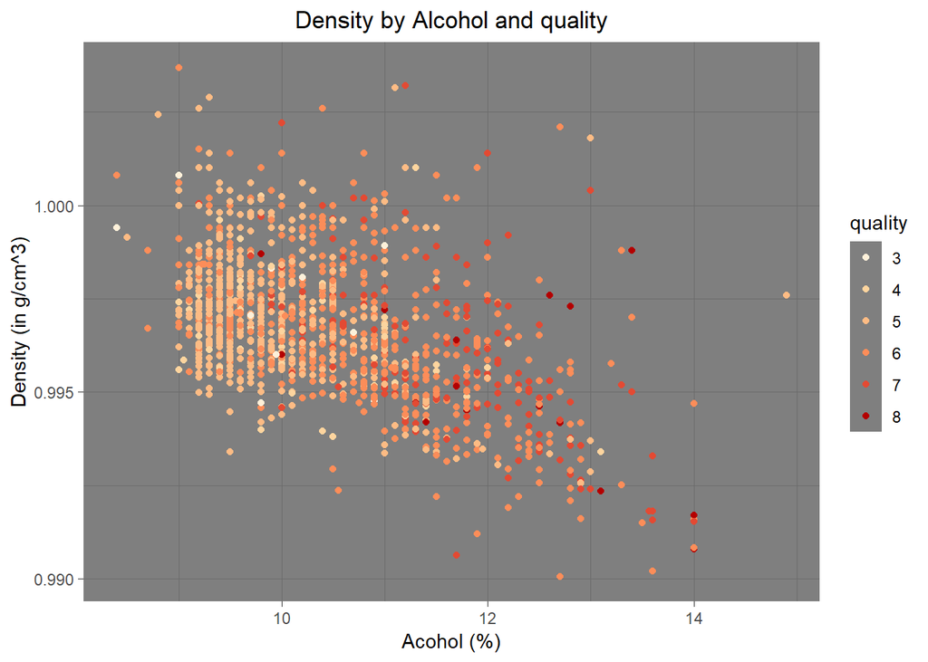

### Description One

Alcohol has a negative correlation with density, meaning that, as the alcohol percentage increases, the density decreases. Furthermore, quality tends to increase as the alcohol increases and the density decreases.

### Plot Two

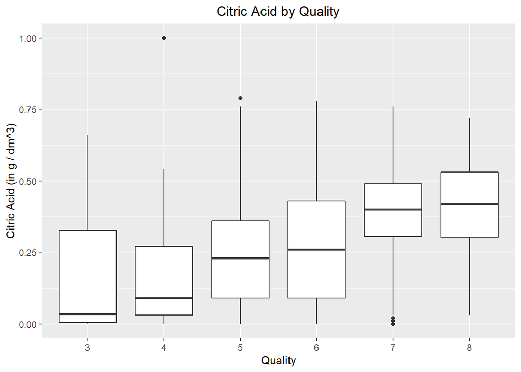

### Description Two

This box plot shows that higher median amounts of citric acid have higher quality.

### Plot Three

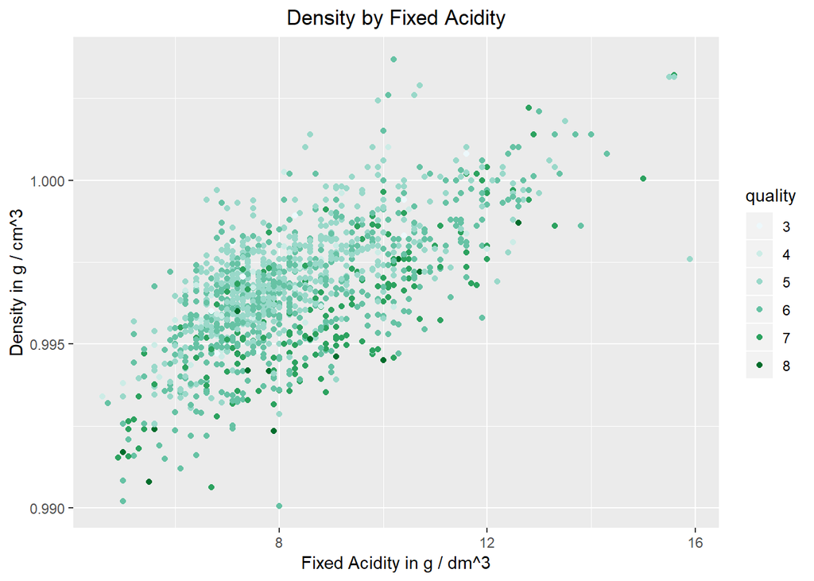

### Description Three

This graph shows that density has a positive correlation with density, and that they both have an effect on quality. Holding density constant, samples with higher fixed acidity have higher quality. Holding fixed acidity constant, samples with higher densities have lower ratings. ——

# Reflection

I performed exploratory data analysis on the red wine dataset, which includes 11 features collected from 1599 samples of red wine and a quality score for each sample. I found many relations that made sense, such as those between pH and fixed acidity, or citric acid and fixed acidity. On the other hand, many relations buffled me, such as those between sulphates and free/total sulfur dioxide, which had no correlation despite what the text file had said. Ultimately, my goal was to discover which factors most strongly affected wine quality and determined whether it will taste good or not. I discovered that these factors include alcohol, density, citric acid, and fixed acidity.

One of the struggles I went through was the lack of abundant data in the dataset. There were too few observations, and most of them had an average quality of 5 or 6, which made it difficult to determine which factors can lead to a high wine quality of 7 or 8. In addition, there was a lot of missing data in the dataset, which also proved to be an obstacle when trying to find patterns, as in some instances, there were barely any observations for red wine with a quality of 3 or 8.

In the future, if more observations can be added to the dataset, it would be much easier to find a more definitive answer to the question of what makes a wine sample taste good, as clearer patterns would arise in the data and they would be much more representative of the entire population.